# Wage Prediction Application

Ari  
Mon Oct 26 01:26:40 2015

Hosted on [Shiny](https://mongolia.shinyapps.io/Project)

### Goal

This application predicts a wage from your age, job class, marital status and education level. It is based on the Wage data in the [ISLR](https://cran.r-project.org/web/packages/ISLR/index.html) package and uses the linear regression model to predict for simplicity and speed.

### Dateset (1 of 3)

```r
str(Wage)
```

```
'data.frame':   3000 obs. of  12 variables:
 $ year      : int  2006 2004 2003 2003 2005 2008 2009 2008 2006 2004 ...
 $ age       : int  18 24 45 43 50 54 44 30 41 52 ...
 $ sex       : Factor w/ 2 levels "1. Male","2. Female": 1 1 1 1 1 1 1 1 1 1 ...
 $ maritl    : Factor w/ 5 levels "1. Never Married",..: 1 1 2 2 4 2 2 1 1 2 ...
 $ race      : Factor w/ 4 levels "1. White","2. Black",..: 1 1 1 3 1 1 4 3 2 1 ...
 $ education : Factor w/ 5 levels "1. < HS Grad",..: 1 4 3 4 2 4 3 3 3 2 ...
 $ region    : Factor w/ 9 levels "1. New England",..: 2 2 2 2 2 2 2 2 2 2 ...
 $ jobclass  : Factor w/ 2 levels "1. Industrial",..: 1 2 1 2 2 2 1 2 2 2 ...
 $ health    : Factor w/ 2 levels "1. <=Good","2. >=Very Good": 1 2 1 2 1 2 2 1 2 2 ...
 $ health_ins: Factor w/ 2 levels "1. Yes","2. No": 2 2 1 1 1 1 1 1 1 1 ...
 $ logwage   : num  4.32 4.26 4.88 5.04 4.32 ...
 $ wage      : num  75 70.5 131 154.7 75 ...
```

### Dateset (2 of 3)

```r
summary(Wage)
```

```
      year           age               sex                    maritl
 Min.   :2003   Min.   :18.00   1. Male  :3000   1. Never Married: 648
 1st Qu.:2004   1st Qu.:33.75   2. Female:   0   2. Married      :2074
 Median :2006   Median :42.00                    3. Widowed      :  19
 Mean   :2006   Mean   :42.41                    4. Divorced     : 204
 3rd Qu.:2008   3rd Qu.:51.00                    5. Separated    :  55
 Max.   :2009   Max.   :80.00

       race                   education                     region
 1. White:2480   1. < HS Grad      :268   2. Middle Atlantic   :3000
 2. Black: 293   2. HS Grad        :971   1. New England       :   0
 3. Asian: 190   3. Some College   :650   3. East North Central:   0
 4. Other:  37   4. College Grad   :685   4. West North Central:   0
                 5. Advanced Degree:426   5. South Atlantic    :   0
                                          6. East South Central:   0
                                          (Other)              :   0
           jobclass               health      health_ins      logwage
 1. Industrial :1544   1. <=Good     : 858   1. Yes:2083   Min.   :3.000
 2. Information:1456   2. >=Very Good:2142   2. No : 917   1st Qu.:4.447
                                                           Median :4.653
                                                           Mean   :4.654
                                                           3rd Qu.:4.857
                                                           Max.   :5.763

      wage
 Min.   : 20.09
 1st Qu.: 85.38
 Median :104.92
 Mean   :111.70
 3rd Qu.:128.68
 Max.   :318.34
```

### Dateset (3 of 3)

```r
head(Wage, 3)
```

```
       year age     sex           maritl     race       education
231655 2006  18 1. Male 1. Never Married 1. White    1. < HS Grad
86582  2004  24 1. Male 1. Never Married 1. White 4. College Grad
161300 2003  45 1. Male       2. Married 1. White 3. Some College
                   region       jobclass         health health_ins
231655 2. Middle Atlantic  1. Industrial      1. <=Good      2. No
86582  2. Middle Atlantic 2. Information 2. >=Very Good      2. No
161300 2. Middle Atlantic  1. Industrial      1. <=Good     1. Yes
        logwage      wage
231655 4.318063  75.04315
86582  4.255273  70.47602
161300 4.875061 130.98218
```

### Plot (1 of 3)

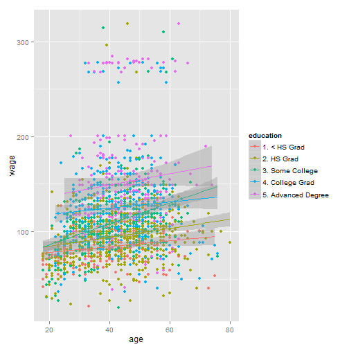

## Observation

It is evident that the wage increases with age. Also, the men with advanced degree earn the highest.

### Plot (2 of 3)

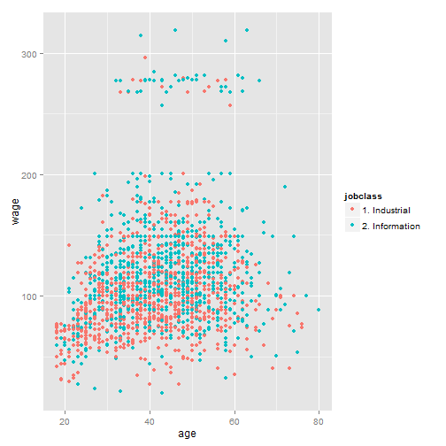

## Observation

It is interesting to note that there is a cluster of men in the information job earning over 200. This outlier may throw off the simple linear model.

### Plot (3 of 3)

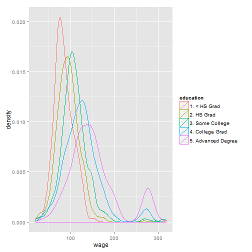

## Observation

Here, we see that, for example, most men with some college education earn 100.

### Model

```r
fit = lm(wage ~ age + jobclass + maritl + education, data = training)
```

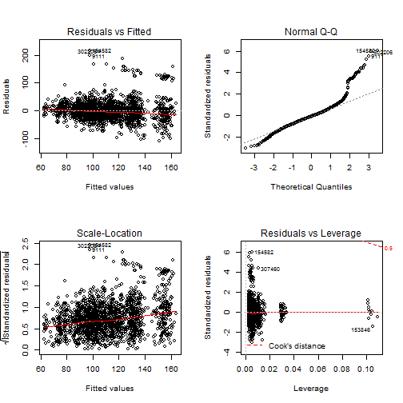

## Goodness of Fit

- The residuals line appears farther from the zero reference line at higher wages. This is due to the high earning cluster of some informational workers. In other words, smaller the wage, more accurate the prediction becomes.
- On the Q-Q plot, the points follow the 45 degree line closely most of the way.

### Prediction

```r
p = round(predict(fit, test), 2)
```

The following are some examples of predictions:

| Age | Job Class | Marital Status | Education | Pred Wage |
| --- | --- | --- | --- | --- |
| 24 | 2. Information | 1. Never Married | 4. College Grad | 108.02 |
| 45 | 1. Industrial | 2. Married | 3. Some College | 113.81 |
| 50 | 2. Information | 4. Divorced | 2. HS Grad | 95.48 |
| 41 | 2. Information | 1. Never Married | 3. Some College | 98.57 |
| 39 | 1. Industrial | 2. Married | 4. College Grad | 126.31 |
| 54 | 2. Information | 2. Married | 2. HS Grad | 107.25 |